# MSCA 37016 Advanced Linear Algebra for Machine Learning

*© 2020 Danny Ng*

## Step 1: What is a convolutional neural net CNN?

A **convolutional neural net CNN** is a kind of neural net deep learning model that has one or more convoluational layers in its network architecture. CNN is a popular choice for computer vision and image machine learning tasks.

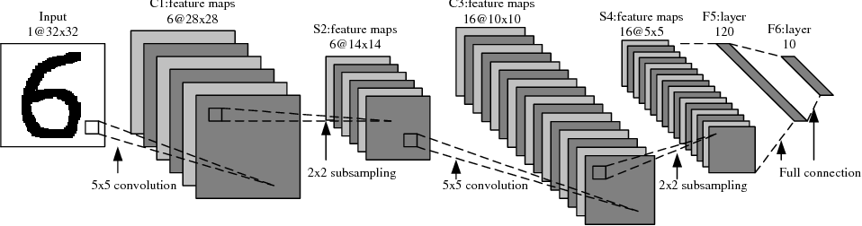

A **convolutional layer** is defined by a **filter / kernel** matrix (in 2-dimension) or tensor (in higher-dimension). This filter is convolved (in the sense of the mathematical https://en.wikipedia.org/wiki/Convolution operation) with each sub-window of the given image to produce one number per sub-window. These numbers become the input features to the next layer of the neural net. The entries of the filter are weights / parameters to be learned during model training.

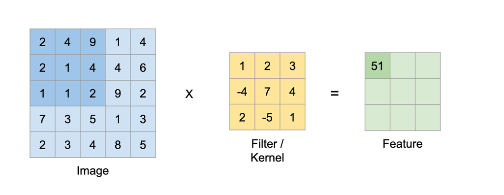

```python
import numpy as np

subwindow = np.array([[2, 4, 9],
                      [2, 1, 4],
                      [1, 1, 2]])

kernel = np.array([[1, 2, 3],
                   [-4, 7, 4],
                   [2, -5, 1]])

subwindow * kernel # * is element-wise multiplication in NumPy
```

```
array([[ 2,  8, 27],
       [-8,  7, 16],
       [ 2, -5,  2]])
```

```python
np.sum(subwindow * kernel) # Sum of the entries
```

```
51
```

Below is an animation of how a filter of size 3x3 is convolved with each of the 25 sub-windows (of the same size 3x3) within the input image of size 7x7 (in blue). The resulting 25 numbers are organized naturally in a 5x5 grid (in green) to become the next layer of input features.

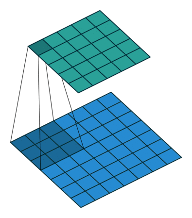

Since the same set of weights (of one filter) is applied to each part of an image, this weight-sharing allows for more efficient feature extraction and modeling.

## Step 2: Doing convolution using FOR loop

We can mimic the computation of a convolutional layer by using a FOR loop and matrix element-wise multiplication. This element-wise operation is similar to a https://en.wikipedia.org/wiki/Kronecker_product

```python
image = np.array([[2, 4, 9, 1, 4],
                  [2, 1, 4, 4, 6],
                  [1, 1, 2, 9, 2],
                  [7, 3, 5, 1, 3],
                  [2, 3, 4, 8, 5]])

i1, i2 = image.shape

i1, i2
```

```
(5, 5)
```

```python
kernel = np.array([[1, 2, 3],
                   [-4, 7, 4],
                   [2, -5, 1]])

k1, k2 = kernel.shape

k1, k2
```

```
(3, 3)
```

```python
output = np.zeros((i1 - k1 + 1, i2 - k2 + 1)) # Initialize a 3x3 matrix

output
```

```
array([[0., 0., 0.],
       [0., 0., 0.],
       [0., 0., 0.]])
```

```python
for i in range(i1 - k1 + 1):
    for j in range(i2 - k2 + 1):
        subwindow = image[i:i+k1, j:j+k2] # Extract sub-window with (i,j) top left corner
        output[i,j] = np.sum(subwindow * kernel) # Convolve with filter
```

```python
output
```

```
array([[ 51.,  66.,  20.],
       [ 31.,  49., 101.],
       [ 15.,  53.,  -2.]])
```

## Step 3: Doing convolutional using matrix-vector multiplication

A matrix-vector multiplication uses a matrix $A$ to transform a vector $\overrightarrow{x}$ into another vector $A\overrightarrow{x}=\overrightarrow{y}$.

The convolution operation above between an image and a kernel can be viewed as a matrix-vector multiplication in disguise. To do so, we first "flatten" the image of size $i_1\times i_2$ into a vector $\overrightarrow{x} \in\mathbb{R}^{i_1 i_2}$ of length $i_1\times i_2$. Then we organize each sub-window convolution operation as a dot product between some row vector (that involves the entries of the filter) and the image vector. Finally, we concatenate these rows together as a matrix $A$ so these dot products can be computed simultaneously via matrix multiplication.

```python
image = np.array([[2, 4, 9, 1, 4],
                  [2, 1, 4, 4, 6],
                  [1, 1, 2, 9, 2],
                  [7, 3, 5, 1, 3],
                  [2, 3, 4, 8, 5]])

row = np.array([[1, 2, 3, 0, 0],
                [-4, 7, 4, 0, 0],
                [2, -5, 1, 0, 0],
                [0, 0, 0, 0, 0],
                [0, 0, 0, 0, 0]])
```

```python
np.sum(image * row)
```

```
51
```

```python
x = image.reshape((25, 1))

x
```

```
array([[2],
       [4],
       [9],
       [1],
       [4],
       [2],
       [1],
       [4],
       [4],
       [6],
       [1],
       [1],
       [2],
       [9],
       [2],
       [7],
       [3],
       [5],
       [1],
       [3],
       [2],
       [3],
       [4],
       [8],
       [5]])
```

```python
row = row.reshape((1, -1))  # -1 means to infer that dimension accordingly

row
```

```
array([[ 1,  2,  3,  0,  0, -4,  7,  4,  0,  0,  2, -5,  1,  0,  0,  0,
         0,  0,  0,  0,  0,  0,  0,  0,  0]])
```

```python
row.shape
```

```
(1, 25)
```

```python
np.dot(row, x) # Matrix multiplication of row vector and column vector
```

```
array([[51]])
```

```python
A = np.zeros(((i1 - k1 + 1) * (i2 - k2 + 1), i1 * i2))

A.shape # (num output entries)x(num image pixel)
```

```
(9, 25)
```

```python
kernel = np.array([[1, 2, 3],
                   [-4, 7, 4],
                   [2, -5, 1]])

r = 0
for i in range(i1 - k1 + 1):
    for j in range(i2 - k2 + 1):
        row = np.zeros((i1, i2))
        row[i:i+k1, j:j+k2] = kernel
        A[r] = row.reshape((1, -1)) # Fill in each row of A
        r += 1
```

```python
A
```

```
array([[ 1.,  2.,  3.,  0.,  0., -4.,  7.,  4.,  0.,  0.,  2., -5.,  1.,
         0.,  0.,  0.,  0.,  0.,  0.,  0.,  0.,  0.,  0.,  0.,  0.],
       [ 0.,  1.,  2.,  3.,  0.,  0., -4.,  7.,  4.,  0.,  0.,  2., -5.,
         1.,  0.,  0.,  0.,  0.,  0.,  0.,  0.,  0.,  0.,  0.,  0.],
       [ 0.,  0.,  1.,  2.,  3.,  0.,  0., -4.,  7.,  4.,  0.,  0.,  2.,
        -5.,  1.,  0.,  0.,  0.,  0.,  0.,  0.,  0.,  0.,  0.,  0.],
       [ 0.,  0.,  0.,  0.,  0.,  1.,  2.,  3.,  0.,  0., -4.,  7.,  4.,
         0.,  0.,  2., -5.,  1.,  0.,  0.,  0.,  0.,  0.,  0.,  0.],
       [ 0.,  0.,  0.,  0.,  0.,  0.,  1.,  2.,  3.,  0.,  0., -4.,  7.,
         4.,  0.,  0.,  2., -5.,  1.,  0.,  0.,  0.,  0.,  0.,  0.],
       [ 0.,  0.,  0.,  0.,  0.,  0.,  0.,  1.,  2.,  3.,  0.,  0., -4.,
         7.,  4.,  0.,  0.,  2., -5.,  1.,  0.,  0.,  0.,  0.,  0.],
       [ 0.,  0.,  0.,  0.,  0.,  0.,  0.,  0.,  0.,  0.,  1.,  2.,  3.,
         0.,  0., -4.,  7.,  4.,  0.,  0.,  2., -5.,  1.,  0.,  0.],
       [ 0.,  0.,  0.,  0.,  0.,  0.,  0.,  0.,  0.,  0.,  0.,  1.,  2.,
         3.,  0.,  0., -4.,  7.,  4.,  0.,  0.,  2., -5.,  1.,  0.],
       [ 0.,  0.,  0.,  0.,  0.,  0.,  0.,  0.,  0.,  0.,  0.,  0.,  1.,
         2.,  3.,  0.,  0., -4.,  7.,  4.,  0.,  0.,  2., -5.,  1.]])
```

```python
y = np.dot(A, x) # Matrix-vector multiplication

y
```

```
array([[ 51.],
       [ 66.],
       [ 20.],
       [ 31.],
       [ 49.],
       [101.],
       [ 15.],
       [ 53.],
       [ -2.]])
```

```python
y.shape
```

```
(9, 1)
```

```python
output = y.reshape((3, 3)) # Un-flatten vector y to 2-dimensional output

output
```

```
array([[ 51.,  66.,  20.],
       [ 31.,  49., 101.],
       [ 15.,  53.,  -2.]])
```